# Optimal Treatment Analysis

## Outcome Variable

**Outcome Variable:** haz

## Predictor Variables

**Intervention Variable:** predfeed3

**Adjustment Set:**

- arm
- sex
- month
- brthmon
- W_mage
- meducyrs
- feducyrs
- hhwealth_quart
- hfoodsec
- W_mhtcm
- W_mwtkg
- W_mbmi
- vagbrth
- W_gagebrth
- W_birthwt
- W_birthlen
- W_nrooms
- W_nchldlt5
- W_parity
- impfloor
- impsan
- safeh20
- delta_W_mage
- delta_meducyrs
- delta_feducyrs
- delta_hhwealth_quart
- delta_hfoodsec
- delta_W_mhtcm
- delta_W_mwtkg
- delta_W_mbmi
- delta_vagbrth
- delta_W_gagebrth
- delta_W_birthwt
- delta_W_birthlen
- delta_W_nrooms
- delta_W_nchldlt5
- delta_W_parity
- delta_impfloor
- delta_impsan
- delta_safeh20

## Stratifying Variables

The analysis was stratified on these variable(s):

- agecat
- studyid
- country

## Data Summary

| agecat | studyid | country | predfeed3 | n_cell | n |
| --- | --- | --- | --- | --- | --- |
| Birth | ki0047075b-MAL-ED | BANGLADESH | 1 | 176 | 215 |
| Birth | ki0047075b-MAL-ED | BANGLADESH | 0 | 39 | 215 |
| Birth | ki0047075b-MAL-ED | BRAZIL | 1 | 24 | 57 |
| Birth | ki0047075b-MAL-ED | BRAZIL | 0 | 33 | 57 |
| Birth | ki0047075b-MAL-ED | INDIA | 1 | 29 | 41 |
| Birth | ki0047075b-MAL-ED | INDIA | 0 | 12 | 41 |
| Birth | ki0047075b-MAL-ED | NEPAL | 1 | 14 | 26 |
| Birth | ki0047075b-MAL-ED | NEPAL | 0 | 12 | 26 |
| Birth | ki0047075b-MAL-ED | PERU | 1 | 150 | 223 |
| Birth | ki0047075b-MAL-ED | PERU | 0 | 73 | 223 |
| Birth | ki0047075b-MAL-ED | SOUTH AFRICA | 1 | 33 | 100 |
| Birth | ki0047075b-MAL-ED | SOUTH AFRICA | 0 | 67 | 100 |
| Birth | ki0047075b-MAL-ED | TANZANIA, UNITED REPUBLIC OF | 1 | 26 | 102 |
| Birth | ki0047075b-MAL-ED | TANZANIA, UNITED REPUBLIC OF | 0 | 76 | 102 |
| Birth | ki1000109-EE | PAKISTAN | 1 | 35 | 35 |
| Birth | ki1000109-EE | PAKISTAN | 0 | 0 | 35 |
| Birth | ki1113344-GMS-Nepal | NEPAL | 1 | 380 | 458 |
| Birth | ki1113344-GMS-Nepal | NEPAL | 0 | 78 | 458 |
| Birth | kiGH5241-JiVitA-3 | BANGLADESH | 1 | 13482 | 14888 |
| Birth | kiGH5241-JiVitA-3 | BANGLADESH | 0 | 1406 | 14888 |
| Birth | kiGH5241-JiVitA-4 | BANGLADESH | 1 | 105 | 116 |
| Birth | kiGH5241-JiVitA-4 | BANGLADESH | 0 | 11 | 116 |
| 6 months | ki0047075b-MAL-ED | BANGLADESH | 1 | 191 | 233 |
| 6 months | ki0047075b-MAL-ED | BANGLADESH | 0 | 42 | 233 |
| 6 months | ki0047075b-MAL-ED | BRAZIL | 1 | 93 | 187 |
| 6 months | ki0047075b-MAL-ED | BRAZIL | 0 | 94 | 187 |
| 6 months | ki0047075b-MAL-ED | INDIA | 1 | 147 | 210 |
| 6 months | ki0047075b-MAL-ED | INDIA | 0 | 63 | 210 |
| 6 months | ki0047075b-MAL-ED | NEPAL | 1 | 113 | 227 |
| 6 months | ki0047075b-MAL-ED | NEPAL | 0 | 114 | 227 |
| 6 months | ki0047075b-MAL-ED | PERU | 1 | 176 | 270 |
| 6 months | ki0047075b-MAL-ED | PERU | 0 | 94 | 270 |
| 6 months | ki0047075b-MAL-ED | SOUTH AFRICA | 1 | 63 | 244 |
| 6 months | ki0047075b-MAL-ED | SOUTH AFRICA | 0 | 181 | 244 |
| 6 months | ki0047075b-MAL-ED | TANZANIA, UNITED REPUBLIC OF | 1 | 64 | 212 |
| 6 months | ki0047075b-MAL-ED | TANZANIA, UNITED REPUBLIC OF | 0 | 148 | 212 |
| 6 months | ki1000109-EE | PAKISTAN | 1 | 39 | 39 |
| 6 months | ki1000109-EE | PAKISTAN | 0 | 0 | 39 |
| 6 months | ki1113344-GMS-Nepal | NEPAL | 1 | 367 | 441 |
| 6 months | ki1113344-GMS-Nepal | NEPAL | 0 | 74 | 441 |
| 6 months | kiGH5241-JiVitA-3 | BANGLADESH | 1 | 8497 | 9307 |
| 6 months | kiGH5241-JiVitA-3 | BANGLADESH | 0 | 810 | 9307 |
| 6 months | kiGH5241-JiVitA-4 | BANGLADESH | 1 | 76 | 88 |
| 6 months | kiGH5241-JiVitA-4 | BANGLADESH | 0 | 12 | 88 |
| 24 months | ki0047075b-MAL-ED | BANGLADESH | 1 | 168 | 205 |
| 24 months | ki0047075b-MAL-ED | BANGLADESH | 0 | 37 | 205 |
| 24 months | ki0047075b-MAL-ED | BRAZIL | 1 | 79 | 152 |
| 24 months | ki0047075b-MAL-ED | BRAZIL | 0 | 73 | 152 |
| 24 months | ki0047075b-MAL-ED | INDIA | 1 | 139 | 202 |
| 24 months | ki0047075b-MAL-ED | INDIA | 0 | 63 | 202 |
| 24 months | ki0047075b-MAL-ED | NEPAL | 1 | 110 | 220 |
| 24 months | ki0047075b-MAL-ED | NEPAL | 0 | 110 | 220 |
| 24 months | ki0047075b-MAL-ED | PERU | 1 | 131 | 198 |
| 24 months | ki0047075b-MAL-ED | PERU | 0 | 67 | 198 |
| 24 months | ki0047075b-MAL-ED | SOUTH AFRICA | 1 | 60 | 228 |
| 24 months | ki0047075b-MAL-ED | SOUTH AFRICA | 0 | 168 | 228 |
| 24 months | ki0047075b-MAL-ED | TANZANIA, UNITED REPUBLIC OF | 1 | 54 | 184 |
| 24 months | ki0047075b-MAL-ED | TANZANIA, UNITED REPUBLIC OF | 0 | 130 | 184 |
| 24 months | ki1000109-EE | PAKISTAN | 1 | 20 | 20 |
| 24 months | ki1000109-EE | PAKISTAN | 0 | 0 | 20 |
| 24 months | ki1113344-GMS-Nepal | NEPAL | 1 | 322 | 384 |
| 24 months | ki1113344-GMS-Nepal | NEPAL | 0 | 62 | 384 |
| 24 months | kiGH5241-JiVitA-3 | BANGLADESH | 1 | 4397 | 4813 |
| 24 months | kiGH5241-JiVitA-3 | BANGLADESH | 0 | 416 | 4813 |
| 24 months | kiGH5241-JiVitA-4 | BANGLADESH | 1 | 136 | 151 |
| 24 months | kiGH5241-JiVitA-4 | BANGLADESH | 0 | 15 | 151 |

The following strata were considered:

- agecat: 24 months, studyid: ki0047075b-MAL-ED, country: BANGLADESH
- agecat: 24 months, studyid: ki0047075b-MAL-ED, country: BRAZIL
- agecat: 24 months, studyid: ki0047075b-MAL-ED, country: INDIA
- agecat: 24 months, studyid: ki0047075b-MAL-ED, country: NEPAL
- agecat: 24 months, studyid: ki0047075b-MAL-ED, country: PERU
- agecat: 24 months, studyid: ki0047075b-MAL-ED, country: SOUTH AFRICA
- agecat: 24 months, studyid: ki0047075b-MAL-ED, country: TANZANIA, UNITED REPUBLIC OF
- agecat: 24 months, studyid: ki1000109-EE, country: PAKISTAN
- agecat: 24 months, studyid: ki1113344-GMS-Nepal, country: NEPAL
- agecat: 24 months, studyid: kiGH5241-JiVitA-3, country: BANGLADESH
- agecat: 24 months, studyid: kiGH5241-JiVitA-4, country: BANGLADESH
- agecat: 6 months, studyid: ki0047075b-MAL-ED, country: BANGLADESH
- agecat: 6 months, studyid: ki0047075b-MAL-ED, country: BRAZIL
- agecat: 6 months, studyid: ki0047075b-MAL-ED, country: INDIA
- agecat: 6 months, studyid: ki0047075b-MAL-ED, country: NEPAL
- agecat: 6 months, studyid: ki0047075b-MAL-ED, country: PERU
- agecat: 6 months, studyid: ki0047075b-MAL-ED, country: SOUTH AFRICA
- agecat: 6 months, studyid: ki0047075b-MAL-ED, country: TANZANIA, UNITED REPUBLIC OF
- agecat: 6 months, studyid: ki1000109-EE, country: PAKISTAN
- agecat: 6 months, studyid: ki1113344-GMS-Nepal, country: NEPAL
- agecat: 6 months, studyid: kiGH5241-JiVitA-3, country: BANGLADESH
- agecat: 6 months, studyid: kiGH5241-JiVitA-4, country: BANGLADESH
- agecat: Birth, studyid: ki0047075b-MAL-ED, country: BANGLADESH
- agecat: Birth, studyid: ki0047075b-MAL-ED, country: BRAZIL
- agecat: Birth, studyid: ki0047075b-MAL-ED, country: INDIA
- agecat: Birth, studyid: ki0047075b-MAL-ED, country: NEPAL
- agecat: Birth, studyid: ki0047075b-MAL-ED, country: PERU
- agecat: Birth, studyid: ki0047075b-MAL-ED, country: SOUTH AFRICA
- agecat: Birth, studyid: ki0047075b-MAL-ED, country: TANZANIA, UNITED REPUBLIC OF
- agecat: Birth, studyid: ki1000109-EE, country: PAKISTAN
- agecat: Birth, studyid: ki1113344-GMS-Nepal, country: NEPAL
- agecat: Birth, studyid: kiGH5241-JiVitA-3, country: BANGLADESH
- agecat: Birth, studyid: kiGH5241-JiVitA-4, country: BANGLADESH

### Dropped Strata

- agecat: Birth, studyid: ki1000109-EE, country: PAKISTAN
- agecat: 6 months, studyid: ki1000109-EE, country: PAKISTAN
- agecat: 24 months, studyid: ki1000109-EE, country: PAKISTAN

## Methods Detail

We’re interested in the causal parameters $E[Y_a]$ for all values of $a \in \mathcal{A}$. These parameters represent the mean outcome if, possibly contrary to fact, we intervened to set all units to have $A=a$. Under the randomization and positivity assumptions, these are identified by the statistical parameters $\psi_a=E_W[E_{Y|A,W}(Y|A=a,W)]$. In addition, we’re interested in the mean of $Y$, $E[Y]$ under no intervention (the observed mean). We will estimate these parameters by using SuperLearner to fit the relevant likelihood factors – $E_{Y|A,W}(Y|A=a,W)$ and $p(A=a|W)$, and then updating our likelihood fit using a joint TMLE.

For unadjusted analyses ($W=\{\}$), initial likelihoods were estimated using Lrnr_glm to estimate the simple $E(Y|A)$ and Lrnr_mean to estimate $p(A)$. For adjusted analyses, a small library containing Lrnr_glmnet, Lrnr_xgboost, and Lrnr_mean was used.

Having estimated these parameters, we will then use the delta method to estimate relative risks and attributable risks relative to a prespecified baseline level of $A$.

# Results Detail

## Results Plots

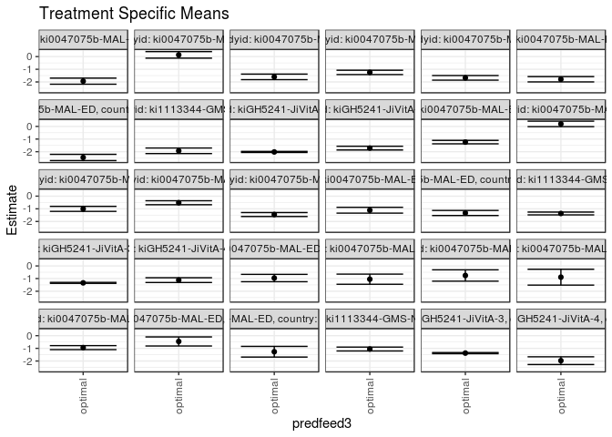

## Results Table

### Parameter: TSM

| agecat | studyid | country | intervention_level | baseline_level | estimate | ci_lower | ci_upper |
| --- | --- | --- | --- | --- | --- | --- | --- |
| Birth | ki0047075b-MAL-ED | BANGLADESH | optimal | observed | -0.9573099 | -1.2467252 | -0.6678946 |
| Birth | ki0047075b-MAL-ED | BRAZIL | optimal | observed | -1.0488284 | -1.4501449 | -0.6475119 |
| Birth | ki0047075b-MAL-ED | INDIA | optimal | observed | -0.7566497 | -1.2054271 | -0.3078723 |
| Birth | ki0047075b-MAL-ED | NEPAL | optimal | observed | -0.8892183 | -1.5152655 | -0.2631712 |
| Birth | ki0047075b-MAL-ED | PERU | optimal | observed | -0.9429709 | -1.1006894 | -0.7852524 |
| Birth | ki0047075b-MAL-ED | SOUTH AFRICA | optimal | observed | -0.4546261 | -0.8124654 | -0.0967868 |
| Birth | ki0047075b-MAL-ED | TANZANIA, UNITED REPUBLIC OF | optimal | observed | -1.2675897 | -1.6893129 | -0.8458666 |
| Birth | ki1113344-GMS-Nepal | NEPAL | optimal | observed | -1.0536513 | -1.2084218 | -0.8988808 |
| Birth | kiGH5241-JiVitA-3 | BANGLADESH | optimal | observed | -1.3750482 | -1.4202031 | -1.3298933 |
| Birth | kiGH5241-JiVitA-4 | BANGLADESH | optimal | observed | -1.9727807 | -2.2787524 | -1.6668089 |
| 6 months | ki0047075b-MAL-ED | BANGLADESH | optimal | observed | -1.2408552 | -1.3757706 | -1.1059398 |
| 6 months | ki0047075b-MAL-ED | BRAZIL | optimal | observed | 0.1954699 | -0.0202790 | 0.4112188 |
| 6 months | ki0047075b-MAL-ED | INDIA | optimal | observed | -1.0034430 | -1.2010952 | -0.8057908 |
| 6 months | ki0047075b-MAL-ED | NEPAL | optimal | observed | -0.5199973 | -0.6768687 | -0.3631260 |
| 6 months | ki0047075b-MAL-ED | PERU | optimal | observed | -1.4509658 | -1.6067691 | -1.2951625 |
| 6 months | ki0047075b-MAL-ED | SOUTH AFRICA | optimal | observed | -1.1113392 | -1.3423601 | -0.8803184 |
| 6 months | ki0047075b-MAL-ED | TANZANIA, UNITED REPUBLIC OF | optimal | observed | -1.3295938 | -1.5307162 | -1.1284713 |
| 6 months | ki1113344-GMS-Nepal | NEPAL | optimal | observed | -1.3678909 | -1.4792319 | -1.2565500 |
| 6 months | kiGH5241-JiVitA-3 | BANGLADESH | optimal | observed | -1.3385375 | -1.3778302 | -1.2992447 |
| 6 months | kiGH5241-JiVitA-4 | BANGLADESH | optimal | observed | -1.1221872 | -1.3106075 | -0.9337670 |
| 24 months | ki0047075b-MAL-ED | BANGLADESH | optimal | observed | -1.9377118 | -2.1783948 | -1.6970288 |
| 24 months | ki0047075b-MAL-ED | BRAZIL | optimal | observed | 0.1375191 | -0.1212524 | 0.3962906 |
| 24 months | ki0047075b-MAL-ED | INDIA | optimal | observed | -1.6012038 | -1.8211893 | -1.3812183 |
| 24 months | ki0047075b-MAL-ED | NEPAL | optimal | observed | -1.2457057 | -1.4164397 | -1.0749717 |
| 24 months | ki0047075b-MAL-ED | PERU | optimal | observed | -1.6770059 | -1.8586360 | -1.4953758 |
| 24 months | ki0047075b-MAL-ED | SOUTH AFRICA | optimal | observed | -1.7882785 | -1.9977951 | -1.5787619 |
| 24 months | ki0047075b-MAL-ED | TANZANIA, UNITED REPUBLIC OF | optimal | observed | -2.4554827 | -2.7026251 | -2.2083404 |
| 24 months | ki1113344-GMS-Nepal | NEPAL | optimal | observed | -1.9293142 | -2.1501096 | -1.7085188 |
| 24 months | kiGH5241-JiVitA-3 | BANGLADESH | optimal | observed | -2.0192682 | -2.0628644 | -1.9756719 |
| 24 months | kiGH5241-JiVitA-4 | BANGLADESH | optimal | observed | -1.7153202 | -1.8634373 | -1.5672030 |

### Parameter: E(Y)

| agecat | studyid | country | intervention_level | baseline_level | estimate | ci_lower | ci_upper |
| --- | --- | --- | --- | --- | --- | --- | --- |
| Birth | ki0047075b-MAL-ED | BANGLADESH | observed | observed | -1.0949767 | -1.2319917 | -0.9579618 |
| Birth | ki0047075b-MAL-ED | BRAZIL | observed | observed | -0.6996491 | -0.9856018 | -0.4136965 |
| Birth | ki0047075b-MAL-ED | INDIA | observed | observed | -1.2075610 | -1.5261540 | -0.8889679 |
| Birth | ki0047075b-MAL-ED | NEPAL | observed | observed | -0.8234615 | -1.1896049 | -0.4573182 |
| Birth | ki0047075b-MAL-ED | PERU | observed | observed | -0.8753812 | -0.9932108 | -0.7575515 |
| Birth | ki0047075b-MAL-ED | SOUTH AFRICA | observed | observed | -0.5797000 | -0.7788298 | -0.3805702 |
| Birth | ki0047075b-MAL-ED | TANZANIA, UNITED REPUBLIC OF | observed | observed | -1.1086275 | -1.3310338 | -0.8862211 |
| Birth | ki1113344-GMS-Nepal | NEPAL | observed | observed | -1.0555240 | -1.1550843 | -0.9559638 |
| Birth | kiGH5241-JiVitA-3 | BANGLADESH | observed | observed | -1.3843216 | -1.4102231 | -1.3584201 |
| Birth | kiGH5241-JiVitA-4 | BANGLADESH | observed | observed | -1.6073276 | -1.8105798 | -1.4040753 |
| 6 months | ki0047075b-MAL-ED | BANGLADESH | observed | observed | -1.2248069 | -1.3446487 | -1.1049651 |
| 6 months | ki0047075b-MAL-ED | BRAZIL | observed | observed | 0.0641266 | -0.0913400 | 0.2195931 |
| 6 months | ki0047075b-MAL-ED | INDIA | observed | observed | -1.2002063 | -1.3275718 | -1.0728409 |
| 6 months | ki0047075b-MAL-ED | NEPAL | observed | observed | -0.5628634 | -0.6765658 | -0.4491611 |
| 6 months | ki0047075b-MAL-ED | PERU | observed | observed | -1.3153519 | -1.4229629 | -1.2077408 |
| 6 months | ki0047075b-MAL-ED | SOUTH AFRICA | observed | observed | -1.0665369 | -1.1970117 | -0.9360620 |
| 6 months | ki0047075b-MAL-ED | TANZANIA, UNITED REPUBLIC OF | observed | observed | -1.4030503 | -1.5292443 | -1.2768563 |
| 6 months | ki1113344-GMS-Nepal | NEPAL | observed | observed | -1.3499849 | -1.4387386 | -1.2612312 |
| 6 months | kiGH5241-JiVitA-3 | BANGLADESH | observed | observed | -1.3470624 | -1.3756620 | -1.3184628 |
| 6 months | kiGH5241-JiVitA-4 | BANGLADESH | observed | observed | -1.1994318 | -1.3808291 | -1.0180345 |
| 24 months | ki0047075b-MAL-ED | BANGLADESH | observed | observed | -2.0021951 | -2.1308572 | -1.8735330 |
| 24 months | ki0047075b-MAL-ED | BRAZIL | observed | observed | -0.0151974 | -0.1917967 | 0.1614019 |
| 24 months | ki0047075b-MAL-ED | INDIA | observed | observed | -1.8978960 | -2.0332143 | -1.7625777 |
| 24 months | ki0047075b-MAL-ED | NEPAL | observed | observed | -1.3153636 | -1.4359803 | -1.1947469 |
| 24 months | ki0047075b-MAL-ED | PERU | observed | observed | -1.7432323 | -1.8646545 | -1.6218102 |
| 24 months | ki0047075b-MAL-ED | SOUTH AFRICA | observed | observed | -1.6467544 | -1.7856657 | -1.5078431 |
| 24 months | ki0047075b-MAL-ED | TANZANIA, UNITED REPUBLIC OF | observed | observed | -2.6763587 | -2.8207363 | -2.5319811 |
| 24 months | ki1113344-GMS-Nepal | NEPAL | observed | observed | -1.8752995 | -1.9688053 | -1.7817937 |
| 24 months | kiGH5241-JiVitA-3 | BANGLADESH | observed | observed | -2.0239144 | -2.0607740 | -1.9870548 |
| 24 months | kiGH5241-JiVitA-4 | BANGLADESH | observed | observed | -1.7726490 | -1.9111913 | -1.6341067 |

### Parameter: PAR

| agecat | studyid | country | intervention_level | baseline_level | estimate | ci_lower | ci_upper |
| --- | --- | --- | --- | --- | --- | --- | --- |
| Birth | ki0047075b-MAL-ED | BANGLADESH | optimal | observed | -0.1376669 | -0.4024459 | 0.1271121 |
| Birth | ki0047075b-MAL-ED | BRAZIL | optimal | observed | 0.3491793 | 0.0164086 | 0.6819500 |
| Birth | ki0047075b-MAL-ED | INDIA | optimal | observed | -0.4509113 | -0.8976780 | -0.0041446 |
| Birth | ki0047075b-MAL-ED | NEPAL | optimal | observed | 0.0657568 | -0.3942421 | 0.5257557 |
| Birth | ki0047075b-MAL-ED | PERU | optimal | observed | 0.0675897 | -0.0413108 | 0.1764903 |
| Birth | ki0047075b-MAL-ED | SOUTH AFRICA | optimal | observed | -0.1250739 | -0.4209023 | 0.1707545 |
| Birth | ki0047075b-MAL-ED | TANZANIA, UNITED REPUBLIC OF | optimal | observed | 0.1589623 | -0.1371958 | 0.4551203 |
| Birth | ki1113344-GMS-Nepal | NEPAL | optimal | observed | -0.0018727 | -0.1095007 | 0.1057553 |
| Birth | kiGH5241-JiVitA-3 | BANGLADESH | optimal | observed | -0.0092734 | -0.0442528 | 0.0257061 |
| Birth | kiGH5241-JiVitA-4 | BANGLADESH | optimal | observed | 0.3654531 | 0.1614292 | 0.5694769 |
| 6 months | ki0047075b-MAL-ED | BANGLADESH | optimal | observed | 0.0160483 | -0.0613097 | 0.0934063 |
| 6 months | ki0047075b-MAL-ED | BRAZIL | optimal | observed | -0.1313434 | -0.2890133 | 0.0263266 |
| 6 months | ki0047075b-MAL-ED | INDIA | optimal | observed | -0.1967634 | -0.3571859 | -0.0363408 |
| 6 months | ki0047075b-MAL-ED | NEPAL | optimal | observed | -0.0428661 | -0.1538640 | 0.0681318 |
| 6 months | ki0047075b-MAL-ED | PERU | optimal | observed | 0.1356139 | 0.0314080 | 0.2398198 |
| 6 months | ki0047075b-MAL-ED | SOUTH AFRICA | optimal | observed | 0.0448023 | -0.1574231 | 0.2470278 |
| 6 months | ki0047075b-MAL-ED | TANZANIA, UNITED REPUBLIC OF | optimal | observed | -0.0734566 | -0.2369939 | 0.0900808 |
| 6 months | ki1113344-GMS-Nepal | NEPAL | optimal | observed | 0.0179060 | -0.0755465 | 0.1113586 |
| 6 months | kiGH5241-JiVitA-3 | BANGLADESH | optimal | observed | -0.0085250 | -0.0355494 | 0.0184995 |
| 6 months | kiGH5241-JiVitA-4 | BANGLADESH | optimal | observed | -0.0772446 | -0.1643772 | 0.0098880 |
| 24 months | ki0047075b-MAL-ED | BANGLADESH | optimal | observed | -0.0644833 | -0.2602221 | 0.1312555 |
| 24 months | ki0047075b-MAL-ED | BRAZIL | optimal | observed | -0.1527165 | -0.3449994 | 0.0395664 |
| 24 months | ki0047075b-MAL-ED | INDIA | optimal | observed | -0.2966922 | -0.4763512 | -0.1170332 |
| 24 months | ki0047075b-MAL-ED | NEPAL | optimal | observed | -0.0696579 | -0.1856364 | 0.0463206 |
| 24 months | ki0047075b-MAL-ED | PERU | optimal | observed | -0.0662264 | -0.1856407 | 0.0531878 |
| 24 months | ki0047075b-MAL-ED | SOUTH AFRICA | optimal | observed | 0.1415241 | -0.0430797 | 0.3261279 |
| 24 months | ki0047075b-MAL-ED | TANZANIA, UNITED REPUBLIC OF | optimal | observed | -0.2208760 | -0.4216994 | -0.0200525 |
| 24 months | ki1113344-GMS-Nepal | NEPAL | optimal | observed | 0.0540147 | -0.1375563 | 0.2455857 |
| 24 months | kiGH5241-JiVitA-3 | BANGLADESH | optimal | observed | -0.0046462 | -0.0301269 | 0.0208345 |
| 24 months | kiGH5241-JiVitA-4 | BANGLADESH | optimal | observed | -0.0573288 | -0.0962092 | -0.0184485 |